# Pilot Study — Targeted Lipid Annotation

RT correction, annotation, normalization and quality control (POS + NEG)

Author

CEMBIO-EURAC Team

Published

April 20, 2026

# Overview

**Study-specific instance**

This is the **combined** annotation for the **pilot study** (BμS device comparison), running positive and negative ionization modes in parallel loops. Expects preprocessed objects from `Preprocessing.qmd`.

This is the second step of the targeted lipidomics workflow. It handles **RT correction, annotation, normalization and QC** for targeted lipidomic profiling using LC-MS data. It expects preprocessed objects from `Preprocessing.qmd`.

## Required Input Files

1. **Preprocessed objects** from `Preprocessing.qmd` in `positive/objects/` and `negative/objects/`
2. **Lipid database** (`LipidDatabase_R.xlsx`) in this folder
3. **Reference lipid lists** (`positive/pos_lipid_reference_set.xlsx`, `negative/neg_lipid_reference_set.xlsx`)

# Configuration

**@SARA:**

Maybe we can create a shared configuration document that is loaded from both `Preprocessing.qmd` and `Annotation.qmd` to avoid duplicating configuration chunks

Set the analysis parameters here. `STUDY_ID` and `SAVE_PREFIX` must match what was used in `Preprocessing.qmd`.

```r
# ============================================================================
# PILOT STUDY CONFIGURATION
# ============================================================================

# Project root: relative path to the repository root (R/ helpers live there)
PROJECT_ROOT <- "../.."

# Study identifier: must match the value used in Preprocessing.qmd
STUDY_ID <- "pilot"

# Prefix for saved objects — must match the value used in Preprocessing.qmd
SAVE_PREFIX <- "posNegExp"

# Number of CPU cores for parallel processing
CORES_NB <- 4

# m/z tolerance used during preprocessing (needed for grouping parameters)
PPM <- 10

# Matching parameters
MATCH_PPM             <- 20
MATCH_RT_TOL          <- 20
ISOPEAK_SIM_THRESHOLD <- 0.78

# QC filtering
RSD_THRESHOLD <- 0.3

# Volume correction factors (specific to pilot study)
VOLUME_FACTORS <- list(
    "W" = 2.5,   # W-DBS: smaller volume injected
    "P" = 1.08   # Plasma: slight adjustment
)

# Expected sample types (for validation and CV summary)
EXPECTED_SAMPLE_TYPES <- c("QC", "M-VAMS", "W-DBS", "C-qDBS", "Plasma")

# Color palette for sample types
SAMPLE_TYPE_COLORS <- c(
    "QC"     = "#999999",
    "M-VAMS" = "#377EB8",
    "W-DBS"  = "#E41A1C",
    "C-qDBS" = "#4DAF4A",
    "Plasma" = "#984EA3"
)

# --- Per-mode configuration ---
IS_FILE_POS  <- "positive/pos_lipid_reference_set.xlsx"
IS_FILE_NEG  <- "negative/neg_lipid_reference_set.xlsx"
DB_SHEET_POS <- 4L
DB_SHEET_NEG <- 5L
RT_COL_POS   <- "RT ESI(+) (min)"
RT_COL_NEG   <- "RT ESI(\u2013) (min)"
```

# Setup

## Load Packages and Helper Functions

```r
source(file.path(PROJECT_ROOT, "R/pos_neg_exp.R"))
source(file.path(PROJECT_ROOT, "R/lipid_helpers.R"))
load_lipid_packages(verbose = TRUE)
```

## Setup Paths and Parallel Processing

```r
OBJECTS_DIR         <- "objects"            # combined POS+NEG objects (from Preprocessing.qmd)
OBJECTS_DIR_POS     <- "positive/objects"
OBJECTS_DIR_NEG     <- "negative/objects"
REF_LIPID_DIR_POS   <- "positive/figures/ref_lipid_image"
REF_LIPID_DIR_NEG   <- "negative/figures/ref_lipid_image"
ISO_PATTERN_DIR_POS <- "positive/figures/iso_pattern_check"
ISO_PATTERN_DIR_NEG <- "negative/figures/iso_pattern_check"

for (.d in c(
    OBJECTS_DIR_POS, OBJECTS_DIR_NEG,
    REF_LIPID_DIR_POS, REF_LIPID_DIR_NEG,
    ISO_PATTERN_DIR_POS, ISO_PATTERN_DIR_NEG
)) {
    dir.create(.d, recursive = TRUE, showWarnings = FALSE)
}
rm(.d)

if (.Platform$OS.type == "unix") {
    register(MulticoreParam(CORES_NB))
} else {
    register(SnowParam(CORES_NB))
}
```

## Validate Lipid Database

```r
for (.pol in c("pos", "neg")) {
    validate_lipid_database(
        db_path  = "LipidDatabase_R.xlsx",
        sheet    = if (.pol == "pos") DB_SHEET_POS else DB_SHEET_NEG,
        polarity = .pol,
        rt_col   = if (.pol == "pos") RT_COL_POS else RT_COL_NEG
    )
}
rm(.pol)
```

# Load Preprocessed Data

Load the preprocessed `XcmsExperiment` and `SummarizedExperiment` objects generated by `Preprocessing.qmd`.

```r
mse      <- readRDS(file.path(OBJECTS_DIR,
                              paste0(SAVE_PREFIX, "_preprocessed_mse.rds")))
res_both <- readRDS(file.path(OBJECTS_DIR,
                              paste0(SAVE_PREFIX, "_preprocessed_res.rds")))

mse_pos <- posMode(mse)
mse_neg <- negMode(mse)
res_pos <- posMode(res_both)
res_neg <- negMode(res_both)

message("\u2713 Loaded PosNegXcmsExp \u2014 ",
        length(mse_pos), " samples (pos), ",
        length(mse_neg), " samples (neg)")
message("\u2713 Loaded PosNegSumExp  \u2014 ",
        nrow(res_pos), " features (pos), ",
        nrow(res_neg), " features (neg)")

# Load reference lipids and extract EICs for both modes
intern_standard_pos <- prepare_reference_lipids(
    IS_FILE_POS, rt_window_left = 30, rt_window_right = 15
)
intern_standard_neg <- prepare_reference_lipids(
    IS_FILE_NEG, rt_window_left = 30, rt_window_right = 20
)
eic_is_pos <- extract_is_eics(mse_pos, intern_standard_pos)
eic_is_neg <- extract_is_eics(mse_neg, intern_standard_neg)
fdata_pos  <- fData(eic_is_pos)
fdata_neg  <- fData(eic_is_neg)

# Color palette (same sample structure for both modes)
palette_sample_type <- create_color_palette(
    mse_pos,
    column        = "sample_type",
    custom_colors = SAMPLE_TYPE_COLORS
)
```

# Database RT Correction

Fit a polynomial model to correct library retention times based on observed shifts in reference lipids.

```r
for (POLARITY in c("pos", "neg")) {
    intern_standard <- if (POLARITY == "pos") intern_standard_pos else intern_standard_neg
    eic_is          <- if (POLARITY == "pos") eic_is_pos else eic_is_neg
    .ref_lipid_dir  <- if (POLARITY == "pos") REF_LIPID_DIR_POS else REF_LIPID_DIR_NEG

    message("\n=== RT Correction: ", toupper(POLARITY), " ===")

    group <- eic_is$sample_type
    group[group == "QC"] <- NA
    group <- as.factor(group)
    param_group <- PeakDensityParam(
        sampleGroups = group,
        minFraction  = 0.5,
        binSize      = 0.01,
        ppm          = PPM,
        bw           = 2
    )

    rt_fit <- fit_rt_correction(
        eic_is, intern_standard, param_group,
        poly_degree = 6,
        output_dir  = .ref_lipid_dir
    )
    print(summary(rt_fit$fit))
    validate_rt_correction(rt_fit, min_r_squared = 0.90, max_residual = 15)
    message(POLARITY, " RT correction R\u00b2 = ",
            round(summary(rt_fit$fit)$r.squared, 4))

    rt_fit_list[[POLARITY]] <- rt_fit
}
```

```
Call:
lm(formula = exp_rt ~ poly(ref_rt, poly_degree, raw = TRUE))

Residuals:
    Min      1Q  Median      3Q     Max
-7.1246 -1.5301 -0.0568  2.6348  3.8468

Coefficients:
                                         Estimate Std. Error t value Pr(>|t|)
(Intercept)                            -3.129e+00  1.239e+01  -0.253  0.80519
poly(ref_rt, poly_degree, raw = TRUE)1  1.106e+00  3.234e-01   3.421  0.00571
poly(ref_rt, poly_degree, raw = TRUE)2 -1.152e-03  2.695e-03  -0.427  0.67731
poly(ref_rt, poly_degree, raw = TRUE)3  4.463e-06  9.719e-06   0.459  0.65506
poly(ref_rt, poly_degree, raw = TRUE)4 -8.620e-09  1.705e-08  -0.506  0.62318
poly(ref_rt, poly_degree, raw = TRUE)5  8.232e-12  1.438e-11   0.573  0.57842
poly(ref_rt, poly_degree, raw = TRUE)6 -3.068e-15  4.669e-15  -0.657  0.52464

(Intercept)
poly(ref_rt, poly_degree, raw = TRUE)1 **
poly(ref_rt, poly_degree, raw = TRUE)2
poly(ref_rt, poly_degree, raw = TRUE)3
poly(ref_rt, poly_degree, raw = TRUE)4
poly(ref_rt, poly_degree, raw = TRUE)5
poly(ref_rt, poly_degree, raw = TRUE)6
---
Signif. codes:  0 '***' 0.001 '**' 0.01 '*' 0.05 '.' 0.1 ' ' 1

Residual standard error: 3.645 on 11 degrees of freedom
Multiple R-squared:  0.9999,    Adjusted R-squared:  0.9998
F-statistic: 1.696e+04 on 6 and 11 DF,  p-value: < 2.2e-16
```

```
Call:
lm(formula = exp_rt ~ poly(ref_rt, poly_degree, raw = TRUE))

Residuals:
   Min     1Q Median     3Q    Max
-9.621 -2.822 -1.212  1.998 15.401

Coefficients:
                                         Estimate Std. Error t value Pr(>|t|)
(Intercept)                            -9.072e+01  1.135e+02  -0.799    0.438
poly(ref_rt, poly_degree, raw = TRUE)1  3.098e+00  2.423e+00   1.279    0.222
poly(ref_rt, poly_degree, raw = TRUE)2 -1.794e-02  1.927e-02  -0.931    0.368
poly(ref_rt, poly_degree, raw = TRUE)3  7.329e-05  7.356e-05   0.996    0.336
poly(ref_rt, poly_degree, raw = TRUE)4 -1.545e-07  1.451e-07  -1.065    0.305
poly(ref_rt, poly_degree, raw = TRUE)5  1.605e-10  1.427e-10   1.125    0.280
poly(ref_rt, poly_degree, raw = TRUE)6 -6.468e-14  5.532e-14  -1.169    0.262

Residual standard error: 6.792 on 14 degrees of freedom
Multiple R-squared:  0.9992,    Adjusted R-squared:  0.9988
F-statistic:  2806 on 6 and 14 DF,  p-value: < 2.2e-16
```

```r
rm(POLARITY, intern_standard, eic_is, .ref_lipid_dir,
   group, param_group, rt_fit)
```

**📋 USER CHECKPOINT: RT Correction Model**

Review the diagnostic plots in **positive/figures/ref_lipid_image** (positive) and **negative/figures/ref_lipid_image** (negative).

- Red points (reference lipids) should align closely with the fitted curve
- **R² > 0.95** is expected for a good fit; values below 0.90 indicate poor calibration
- **Residuals** should be randomly distributed around zero with no systematic patterns
- Typical residual range: ±10 seconds; larger deviations suggest outlier reference compounds

## Load and Correct Lipid Database

The `prepare_lipid_database()` function handles all database preprocessing:

1. Filter by rank - Removes rank=0 (unconfirmed) entries
2. RT conversion - Minutes → seconds
3. Unique naming - Appends RT rank for lipids with multiple isomers
4. Adduct processing - Calculates theoretical m/z using `adductFormula()`
5. Deuterium handling - Converts D↔︎[2H] notation for formula calculation
6. NA removal - Cleans empty rows from Excel import
7. RT correction - Applies polynomial model from reference lipids

```r
for (POLARITY in c("pos", "neg")) {
    DB_SHEET <- if (POLARITY == "pos") DB_SHEET_POS else DB_SHEET_NEG
    RT_COL   <- if (POLARITY == "pos") RT_COL_POS   else RT_COL_NEG
    rt_fit   <- rt_fit_list[[POLARITY]]

    lipid_database <- prepare_lipid_database(
        db_path  = "LipidDatabase_R.xlsx",
        sheet    = DB_SHEET,
        polarity = POLARITY,
        rt_col   = RT_COL,
        rt_fit   = rt_fit
    )

    lipid_db_list[[POLARITY]] <- lipid_database
}
rm(POLARITY, DB_SHEET, RT_COL, rt_fit, lipid_database)
```

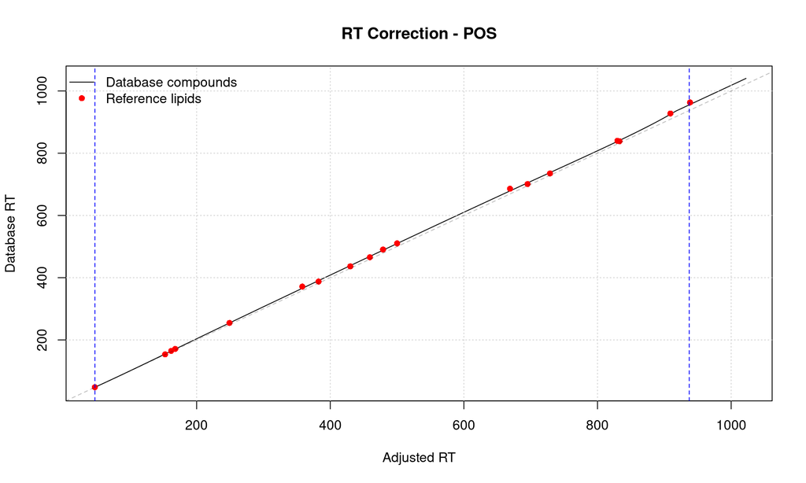

Database RT vs. adjusted RT with reference lipids overlay

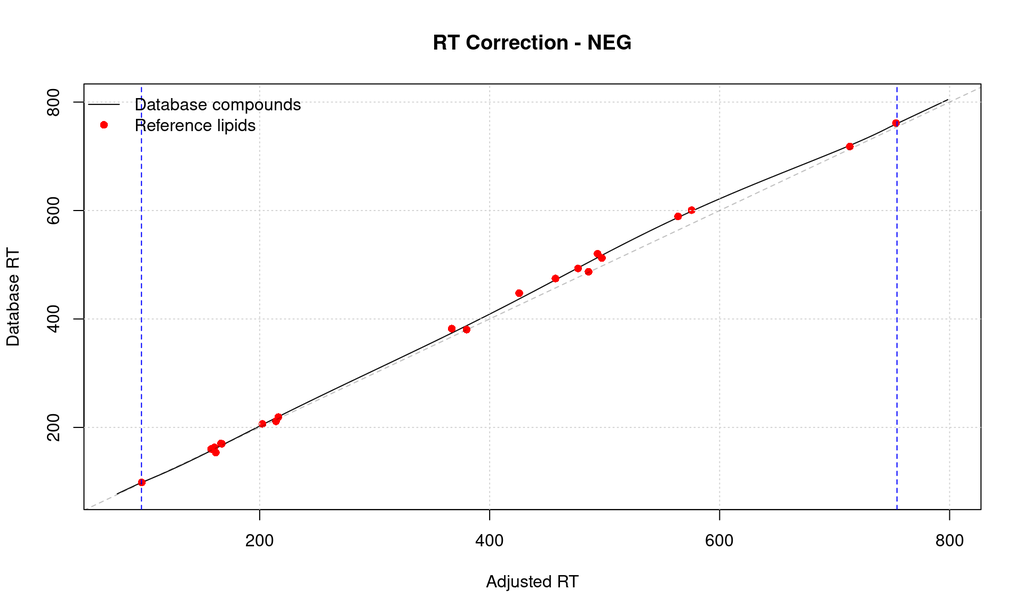

Database RT vs. adjusted RT with reference lipids overlay

```r
for (POLARITY in c("pos", "neg")) {
    rt_fit         <- rt_fit_list[[POLARITY]]
    lipid_database <- lipid_db_list[[POLARITY]]
    intern_standard <- if (POLARITY == "pos") intern_standard_pos
                       else intern_standard_neg

    plot(y = lipid_database$rt_sd, x = lipid_database$rt_adjusted, type = "l",
         xlab = "Adjusted RT", ylab = "Database RT",
         main = paste("RT Correction -", toupper(POLARITY)))
    points(intern_standard$RT ~ rt_fit$exp_rt, col = "red", pch = 16, cex = 1)
    abline(v = min(rt_fit$fit$fitted.values), col = "blue", lwd = 1, lty = 2)
    abline(v = max(rt_fit$fit$fitted.values), col = "blue", lwd = 1, lty = 2)
    grid()
    abline(0, 1, lty = 2, col = "#00000040")
    legend("topleft", legend = c("Database compounds", "Reference lipids"),
           col = c("black", "red"), lty = c(1, NA), pch = c(NA, 16), bty = "n")
}
```

```r
rm(POLARITY, rt_fit, lipid_database, intern_standard)
```

# Annotation / Matching

## Rank 1 Matching

Match features against the lipid database using primary adducts (rank 1). Matching uses both m/z (ppm tolerance) and RT (time tolerance) constraints.

**`PosNegAnnotation` — dual-mode annotation container**

`PosNegAnnotation(pos, neg)` pairs the annotation data frames for the two ionization modes into a single object. Use `posMode()` / `negMode()` to extract either side; functions that operate on both modes (isotope validation, adduct matching, ambiguity resolution) accept the combined object and return an updated one.

```r
annotation <- PosNegAnnotation(
    pos = match_features_to_database(res_pos, lipid_db_list[["pos"]],
                                     ppm = MATCH_PPM, rt_tol = MATCH_RT_TOL),
    neg = match_features_to_database(res_neg, lipid_db_list[["neg"]],
                                     ppm = MATCH_PPM, rt_tol = MATCH_RT_TOL)
)

for (.pol in c("pos", "neg")) {
    .a <- if (.pol == "pos") posMode(annotation) else negMode(annotation)
    validate_matches(annotMatches(.a), min_matches = 10, max_ppm_error = 15)
}
rm(.pol, .a)
```

## Isotope Pattern Validation

**`PosNegXcmsExp` — dual-mode raw-data container**

`PosNegXcmsExp(pos, neg)` bundles both `XcmsExperiment` objects. It is used here because isotope similarity calculation needs access to the raw spectra of **both** modes at the same time (to resolve cross-mode ambiguities). The same `posMode()` / `negMode()` accessors apply.

```r
iso_combined    <- calculate_isotope_similarity(
    PosNegXcmsExp(mse_pos, mse_neg),
    annotation,
    isopeak_threshold    = 2,
    similarity_threshold = ISOPEAK_SIM_THRESHOLD
)
annotation      <- iso_combined$annotation
iso_result_list <- iso_combined$iso_results

for (POLARITY in c("pos", "neg")) {
    .annot <- if (POLARITY == "pos") posMode(annotation) else negMode(annotation)
    message(POLARITY, " matches after isotope filter: ",
            nrow(annotMatches(.annot)))
}
rm(iso_combined, POLARITY, .annot)
```

```r
for (POLARITY in c("pos", "neg")) {
    .iso_dir   <- if (POLARITY == "pos") ISO_PATTERN_DIR_POS else ISO_PATTERN_DIR_NEG
    .annot     <- if (POLARITY == "pos") posMode(annotation) else negMode(annotation)
    iso_result <- iso_result_list[[POLARITY]]

    plot_isotope_patterns(
        annotMatches(.annot),
        iso_result$iso_spectra,
        iso_result$theoretical_spectra,
        .iso_dir
    )
}
rm(POLARITY, .iso_dir, .annot, iso_result)
```

**📋 USER CHECKPOINT: Isotope Pattern Validation**

Review the mirror plots in **positive/figures/iso_pattern_check** (positive) and **negative/figures/iso_pattern_check** (negative).

- Experimental (top) should match theoretical (bottom) patterns
- Check compounds with similarity scores near the threshold; adjust `ISOPEAK_SIM_THRESHOLD` if needed
- Note any false positive matches where patterns clearly don’t align

## Adduct Matching (Rank > 1)

After rank 1 matching, search for secondary adducts that support the identification. Finding multiple adducts for the same lipid increases annotation confidence.

```r
annotation <- match_adducts(annotation, ppm = MATCH_PPM, rt_tol = 5)
```

## Resolve Ambiguities

```r
annotation <- resolve_annotation_ambiguities(annotation)
```

## SM1/SM2 Isomer Resolution

```r
annotation <- resolve_sm_isomers(annotation)

mtched_data_precuration_list <- list(
    pos = annotMatches(posMode(annotation)),
    neg = annotMatches(negMode(annotation))
)
```

## Export Ambiguity Tables for Manual Curation

Export tables for manual review of ambiguous matches:

- Lipid ambiguities: one lipid matches multiple features
- Feature ambiguities: one feature matches multiple lipids (will be merged if not resolved)

```r
for (POLARITY in c("pos", "neg")) {
    ambiguities <- export_ambiguity_tables(
        mtched_data_precuration_list[[POLARITY]],
        lipid_file   = paste0("lipid_ambiguity_resolution_",   POLARITY, ".xlsx"),
        feature_file = paste0("feature_ambiguity_resolution_", POLARITY, ".xlsx")
    )
}
rm(POLARITY, ambiguities)
```

**📋 USER CHECKPOINT: Manual Ambiguity Resolution**

Two Excel files per mode have been created in this folder:

- `lipid_ambiguity_resolution_{pos|neg}.xlsx` — one lipid matches multiple features (DEFAULT: all `keep_row = TRUE`)
- `feature_ambiguity_resolution_{pos|neg}.xlsx` — one feature matches multiple lipids (unresolved entries will be merged)

**Action Required:**

- Open each file
- Set `keep_row = FALSE` for entries you want to remove
- Save the files
- Re-run the **apply-curation** chunk below to apply your decisions

## Apply Manual Curation

```r
for (POLARITY in c("pos", "neg")) {
    # Always start from the pre-curation snapshot for re-runnability
    mtched_data <- mtched_data_precuration_list[[POLARITY]]

    lip_file <- paste0("lipid_ambiguity_resolution_",   POLARITY, ".xlsx")
    ft_file  <- paste0("feature_ambiguity_resolution_", POLARITY, ".xlsx")

    if (file.exists(lip_file)) {
        lipid_amb_res          <- read_excel(lip_file)
        lipid_amb_res$keep_row <- as.logical(lipid_amb_res$keep_row)
        mtch_to_be_rm          <- lipid_amb_res$ntch_idx[!lipid_amb_res$keep_row]
        mtched_data            <- mtched_data[
            !mtched_data$ntch_idx %in% mtch_to_be_rm, ]
    }
    if (file.exists(ft_file)) {
        feature_amb_res          <- read_excel(ft_file)
        feature_amb_res$keep_row <- as.logical(feature_amb_res$keep_row)
        mtch_to_be_rm_ft         <- feature_amb_res$ntch_idx[
            !feature_amb_res$keep_row]
        mtched_data              <- mtched_data[
            !mtched_data$ntch_idx %in% mtch_to_be_rm_ft, ]
    }

    # Merge remaining duplicated features
    mtched_data$nb_annotations <- 1
    fids_ambiguous <- mtched_data$feature_id[duplicated(mtched_data$feature_id)]
    for (i in unique(fids_ambiguous)) {
        idxs <- which(mtched_data$feature_id == i)
        if (length(idxs) > 1) {
            mtched_data$target_lipid_name_unique[idxs[1]] <-
                paste(unique(mtched_data$target_lipid_name_unique[idxs]),
                      collapse = "; ")
            mtched_data$target_adduct[idxs[1]] <-
                paste(unique(mtched_data$target_adduct[idxs]),
                      collapse = "; ")
            mtched_data$nb_annotations[idxs[1]] <- length(idxs)
            mtched_data <- mtched_data[-idxs[-1], ]
        }
    }

    message("Final matched lipids (", POLARITY, "): ", nrow(mtched_data))
    mtched_data_list[[POLARITY]] <- mtched_data
}
rm(POLARITY, mtched_data, lip_file, ft_file, fids_ambiguous)
```

## Annotation Summary

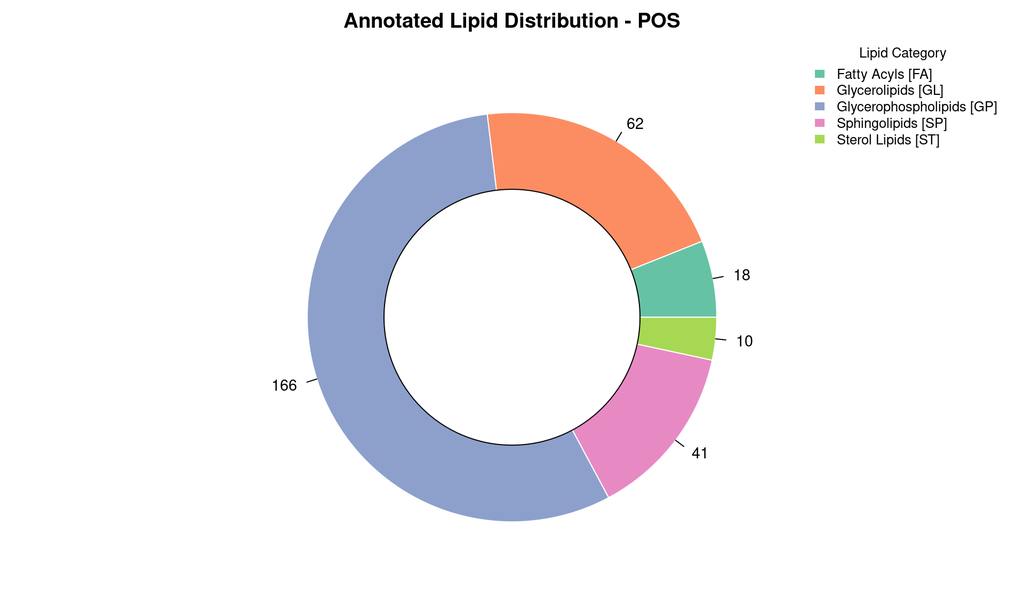

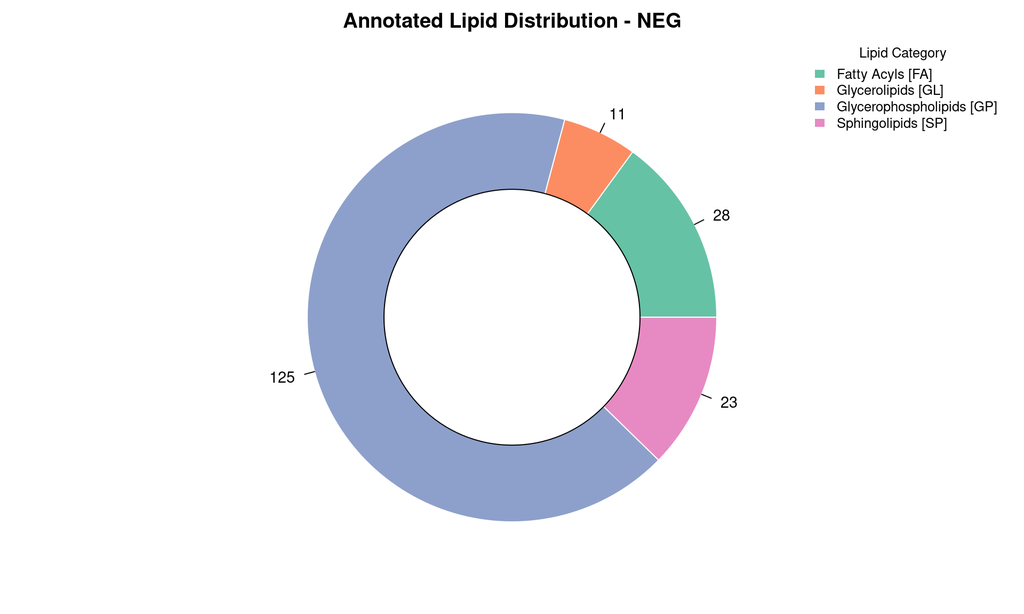

```r
for (POLARITY in c("pos", "neg")) {
    mtched_data  <- mtched_data_list[[POLARITY]]
    lipid_db_r1  <- lipid_db_list[[POLARITY]][lipid_db_list[[POLARITY]]$rank == 1, ]

    n_unique_lipids <- length(unique(mtched_data$target_lipid_name_unique))
    n_db_lipids     <- length(unique(lipid_db_r1$lipid_name_unique))
    coverage        <- n_unique_lipids / n_db_lipids * 100

    message(POLARITY, " final annotation: ", n_unique_lipids, " unique lipids (",
            round(coverage, 1), "% database coverage)")

    counts <- table(mtched_data$`target_LIPID.CATEGORY..ABBREV.`)
    print(plot_lipid_donut(
        counts,
        title = paste("Annotated Lipid Distribution -", toupper(POLARITY))
    ))
}
```

```r
rm(POLARITY, mtched_data, lipid_db_r1, n_unique_lipids, n_db_lipids, coverage,
   counts)
```

# Data Normalization

## Volume Correction

**`PosNegSumExp` — dual-mode quantitative container**

`PosNegSumExp(pos, neg)` wraps two `SummarizedExperiment` objects so that normalization, filtering, and QC steps can be applied consistently to both modes in a single call. Results are split back with `posMode()` / `negMode()` when per-mode access is needed.

```r
res_both <- PosNegSumExp(res_pos, res_neg)
res_both <- apply_volume_correction(res_both, VOLUME_FACTORS,
                                    assay_name     = "raw",
                                    new_assay_name = "raw_corr")
res_both <- apply_volume_correction(res_both, VOLUME_FACTORS,
                                    assay_name     = "raw_filled",
                                    new_assay_name = "corr_filled")
res_corr_list <- list(pos = posMode(res_both), neg = negMode(res_both))
rm(res_both)
```

## Create Annotated Result Object

```r
annotated_res_both <- annotate_features(
    PosNegSumExp(res_corr_list[["pos"]], res_corr_list[["neg"]]),
    mtched_data_list
)
annotated_res_list <- list(pos = posMode(annotated_res_both),
                           neg = negMode(annotated_res_both))
rm(annotated_res_both)
```

## Missing Value Imputation

We impute here only to perform PCA plotting.

```r
for (POLARITY in c("pos", "neg")) {
    annotated_res <- annotated_res_list[[POLARITY]]

    tmp <- apply(assay(annotated_res, "raw_filled"),  MARGIN = 1, na_unidis)
    assays(annotated_res)$raw_filled_imputed <- t(tmp)

    tmp <- apply(assay(annotated_res, "corr_filled"), MARGIN = 1, na_unidis)
    assays(annotated_res)$corr_filled_imputed <- t(tmp)

    annotated_res_list[[POLARITY]] <- annotated_res
}
rm(POLARITY, annotated_res, tmp)
```

## Internal Standard Normalization

```r
annotated_res_both <- PosNegSumExp(
    annotated_res_list[["pos"]],
    annotated_res_list[["neg"]]
)
annotated_res_both <- normalize_by_is(
    annotated_res_both,
    input_assay  = "corr_filled",
    output_assay = "ISnorm_filled",
    is_col       = "target_IS_norm",
    lipid_col    = "target_lipid.name"
)

for (POLARITY in c("pos", "neg")) {
    annotated_res <- if (POLARITY == "pos") posMode(annotated_res_both) else
        negMode(annotated_res_both)

    tmp <- apply(assay(annotated_res, "ISnorm_filled"), MARGIN = 1, na_unidis)
    assays(annotated_res)$ISnorm_filled_imputed <- t(tmp)

    annotated_res_list[[POLARITY]] <- annotated_res
}
rm(POLARITY, annotated_res, tmp, annotated_res_both)
```

# Quality Control

## RSD Filtering

```r
res_unfilt_list <- annotated_res_list

annotated_res_both <- PosNegSumExp(
    annotated_res_list[["pos"]],
    annotated_res_list[["neg"]]
)
annotated_res_both <- filter_by_qc_rsd(annotated_res_both,
                                        threshold = RSD_THRESHOLD)
annotated_res_list[["pos"]] <- posMode(annotated_res_both)
annotated_res_list[["neg"]] <- negMode(annotated_res_both)
rm(annotated_res_both)
```

## Quality Assessment Plots

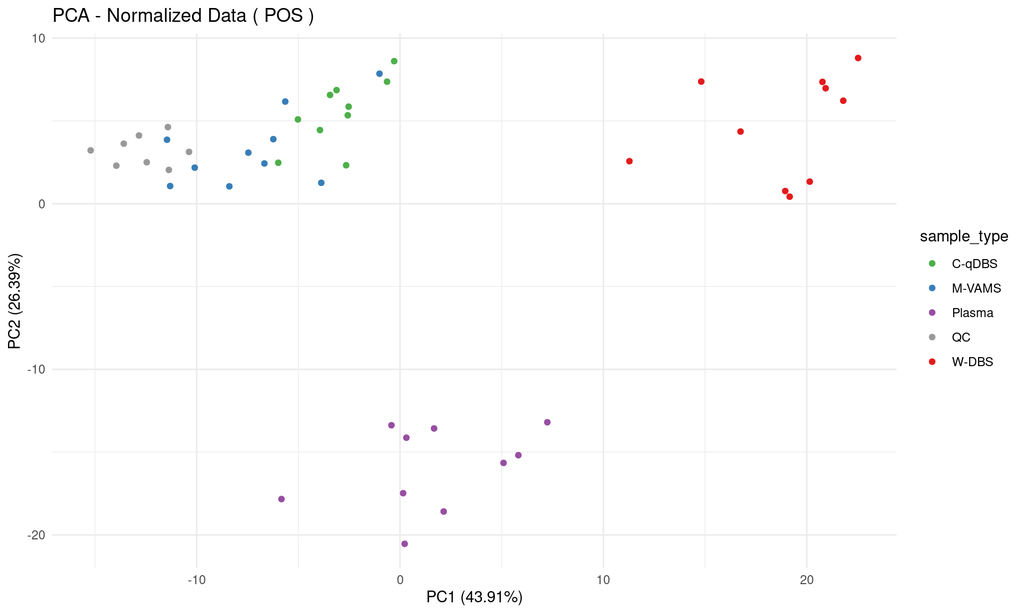

PCA of normalized data colored by sample type

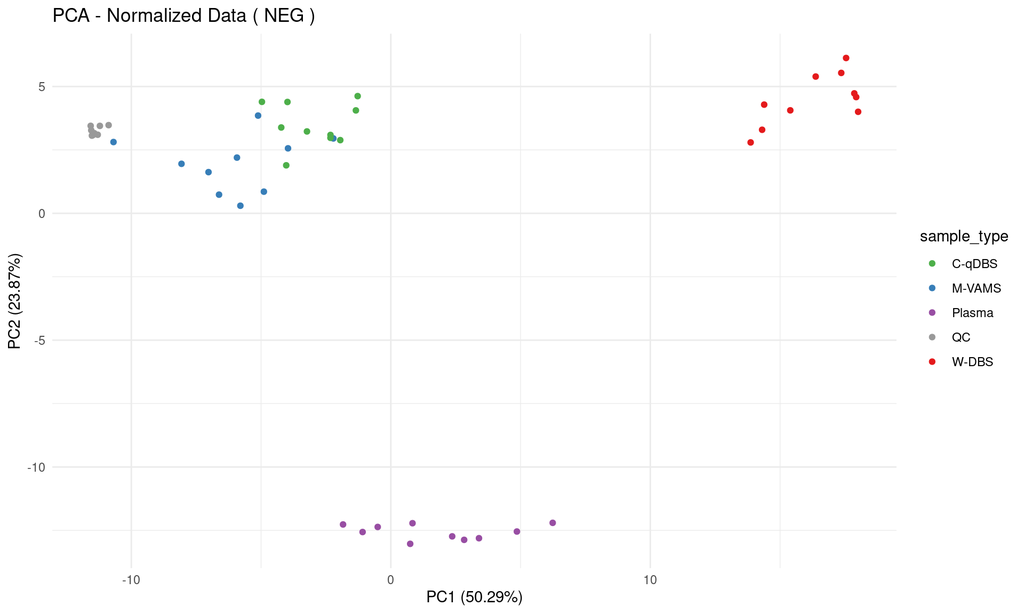

PCA of normalized data colored by sample type

```r
for (POLARITY in c("pos", "neg")) {
    annotated_res <- annotated_res_list[[POLARITY]]

    vals    <- assay(annotated_res, "ISnorm_filled_imputed") |>
        log2() |> t() |> scale(center = TRUE, scale = TRUE)
    pca_res <- prcomp(vals, scale = FALSE, center = FALSE)
    vals_st <- cbind(vals, sample_type = annotated_res$sample_type)

    print(
        autoplot(pca_res, data = vals_st, colour = "sample_type", scale = 0) +
            scale_color_manual(values = palette_sample_type) +
            theme_minimal() +
            ggtitle(paste("PCA - Normalized Data (", toupper(POLARITY), ")"))
    )
}
```

```r
rm(POLARITY, annotated_res, vals, pca_res, vals_st)
```

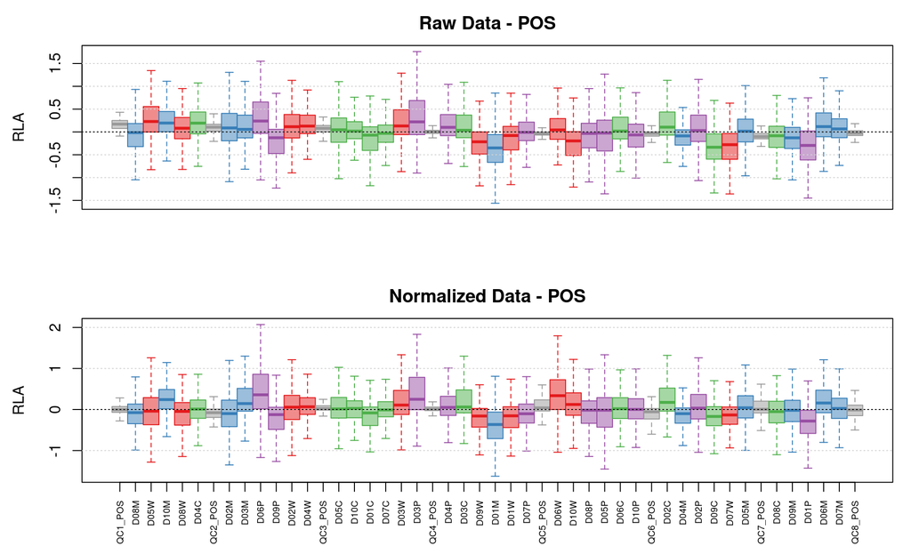

Relative Log Abundance before and after normalization

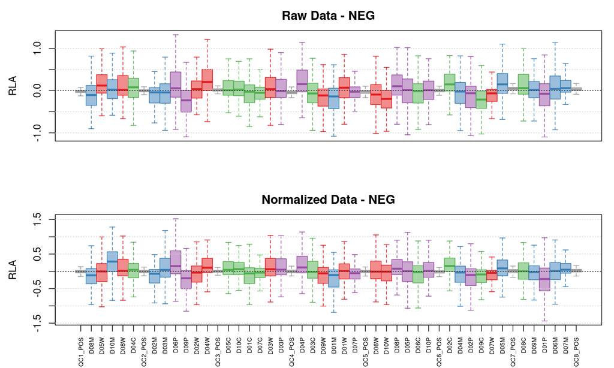

Relative Log Abundance before and after normalization

```r
for (POLARITY in c("pos", "neg")) {
    annotated_res  <- annotated_res_list[[POLARITY]]
    col_sample_ann <- get_sample_colors(annotated_res$sample_type,
                                        palette_sample_type)

    par(mfrow = c(2, 1), mar = c(3.5, 4.5, 2.5, 1))
    boxplot(
        rowRla(assay(annotated_res, "raw_filled"),
               group = annotated_res$sample_type),
        cex = 0.5, pch = 16, ylab = "RLA", border = col_sample_ann,
        col = paste0(col_sample_ann, "80"), outline = FALSE,
        xaxt = "n", main = paste("Raw Data -", toupper(POLARITY)), boxwex = 1
    )
    grid(nx = NA, ny = NULL)
    abline(h = 0, lty = 3)

    boxplot(
        rowRla(assay(annotated_res, "ISnorm_filled"),
               group = annotated_res$sample_type),
        cex = 0.5, pch = 16, ylab = "RLA", border = col_sample_ann,
        col = paste0(col_sample_ann, "80"), outline = FALSE,
        xaxt = "n",
        main = paste("Normalized Data -", toupper(POLARITY)), boxwex = 1
    )
    axis(side = 1, at = seq_len(ncol(annotated_res)),
         labels = annotated_res$sample_name, las = 2, cex.axis = 0.6)
    grid(nx = NA, ny = NULL)
    abline(h = 0, lty = 3)
}
```

```r
rm(POLARITY, annotated_res, col_sample_ann)
```

## CV Summary

```r
for (POLARITY in c("pos", "neg")) {
    annotated_res <- annotated_res_list[[POLARITY]]
    index_study   <- annotated_res$sample_type != "QC"
    index_QC      <- annotated_res$sample_type == "QC"

    sample_res <- cbind(
        QC_raw    = rowRsd(assay(annotated_res, "raw_filled")[, index_QC],
                           na.rm = TRUE, mad = TRUE),
        QC_norm   = rowRsd(assay(annotated_res, "ISnorm_filled")[, index_QC],
                           na.rm = TRUE, mad = TRUE),
        Study_raw  = rowRsd(assay(annotated_res, "raw_filled")[, index_study],
                            na.rm = TRUE, mad = TRUE),
        Study_norm = rowRsd(assay(annotated_res, "ISnorm_filled")[, index_study],
                            na.rm = TRUE, mad = TRUE)
    )

    res_df <- data.frame(
        QC_raw    = quantile(sample_res[, "QC_raw"],    na.rm = TRUE),
        QC_norm   = quantile(sample_res[, "QC_norm"],   na.rm = TRUE),
        Study_raw  = quantile(sample_res[, "Study_raw"],  na.rm = TRUE),
        Study_norm = quantile(sample_res[, "Study_norm"], na.rm = TRUE)
    )

    message(POLARITY, " CV summary:")
    print(kable(res_df, format = "pipe", digits = 3))
}
```

```
|     | QC_raw| QC_norm| Study_raw| Study_norm|
|:----|------:|-------:|---------:|----------:|
|0%   |  0.015|   0.007|     0.068|      0.174|
|25%  |  0.058|   0.052|     0.544|      0.518|
|50%  |  0.087|   0.125|     0.664|      0.605|
|75%  |  0.130|   0.177|     0.788|      0.730|
|100% |  0.482|   0.486|     1.390|      1.275|
```

```
|     | QC_raw| QC_norm| Study_raw| Study_norm|
|:----|------:|-------:|---------:|----------:|
|0%   |  0.004|   0.007|     0.105|      0.226|
|25%  |  0.026|   0.025|     0.513|      0.431|
|50%  |  0.038|   0.035|     0.658|      0.576|
|75%  |  0.057|   0.059|     0.789|      0.721|
|100% |  0.242|   0.250|     1.403|      1.450|
```

```r
rm(POLARITY, annotated_res, index_study, index_QC, sample_res, res_df)
```

# Final Results

```r
for (POLARITY in c("pos", "neg")) {
    annotated_res <- annotated_res_list[[POLARITY]]
    .obj_dir      <- if (POLARITY == "pos") OBJECTS_DIR_POS else OBJECTS_DIR_NEG

    res_qc    <- annotated_res[, annotated_res$sample_type == "QC"]
    res_final <- annotated_res[, annotated_res$sample_type != "QC"]
    rowData(res_final)$qc_cv <- assay(res_qc, "ISnorm_filled") |> rowRsd()

    final_save_path <- file.path(.obj_dir,
                                 paste0(SAVE_PREFIX, "_final_res_", POLARITY))
    if (dir.exists(final_save_path)) unlink(final_save_path, recursive = TRUE)
    saveObject(res_final, final_save_path)
    message("\u2713 Saved final results (", POLARITY, ") to: ", .obj_dir)

    res_final_list[[POLARITY]] <- res_final
}
rm(POLARITY, annotated_res, .obj_dir, res_qc, res_final, final_save_path)

res_final_pos <- res_final_list$pos
res_final_neg <- res_final_list$neg
message("\n\u2713 Annotation complete for both modes.")
```

# Reference

1. Database source: https://doi.org/10.1016/j.jlr.2024.100671
2. Original study (dataset 1): https://doi.org/10.1016/j.microc.2025.113760
3. Metabonaut tutorial: https://rformassspectrometry.github.io/Metabonaut/articles/a-end-to-end-untargeted-metabolomics.html#retention-time-alignment
4. Validation study (dataset 2): https://pubs.acs.org/doi/10.1021/acs.jproteome.5c00480